# Advanced R graphics

Yaping Wang

2022-09-01

# Outline

- Introduction to R graphics
- ggplot2 package
- Data Visualization with ggplot2
- Graphics for Communication

# Introduction to R graphics

### **four graphic systems in R**

1. basic graphics
2. lattice package
3. ggplot2 package
4. grid package

# ggplot2 package

### **What is ggplot2?**

[figure not shown]

ggplot2 is an R package for producing statistical, or data, graphics, and it’s one of the core members of the tidyverse.

Unlike most other graphics packages, ggplot2 has an underlying grammar, based on the Grammar of Graphics, that allows you to compose graphs by combining independent components.

# **General steps of using ggplot2**

1. Prepare the data, usually as a data frame.
2. Enter the data into the ggplot( ) function and specify which graphical properties each variable involved in the graph is mapped to, such as x-coordinates, y-coordinates, colors, shapes, etc.
3. Select a suitable graph type where the function name begins with geom_, such as geom_point( ) represents a scatter plot. The graphic type is abbreviated as geom. Connect the ggplot( ) part with the geom_xxx( ) part with a plus sign.
4. Set the appropriate coordinate system, such as coord_cartesian( ), scale_x_log10( ), etc. Still connect with a plus sign.
5. Set the title and legend position, etc., such as labs( ). Still connect with a plus sign.

# **The Layered Grammar of Graphics**

ggplot2 implements the grammar of graphics, which decomposes a graph task into several subtasks, and as long as each subtask is completed, the graph can be completed.

**Plot = Data + Aesthetics + Geometry**

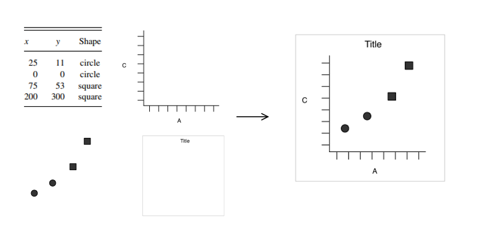

ggplot ( data = <data_frame>,

mapping = aes( <dimension> = <var_name>,

<dimension> = <var_name> ), <…>) +

geom_<graph_type> ( <…> ) +

scale_<mapping>_<type> ( <…> ) +

coord_<type> ( <…> ) +

labs ( <…> )

# Basic scatter plot

- **diffierent ways of install ggplot2 package**

```
#直接安装tidyverse包
install.packages("tidyverse")
#直接安装ggplot2
install.packages("ggplot2")
#从Github上安装最新的版本，先安装devtools(如果没安装的话)
devtools::install_github("tidyverse/ggplot2")
```

- **scatter plots based on mpg data frames**

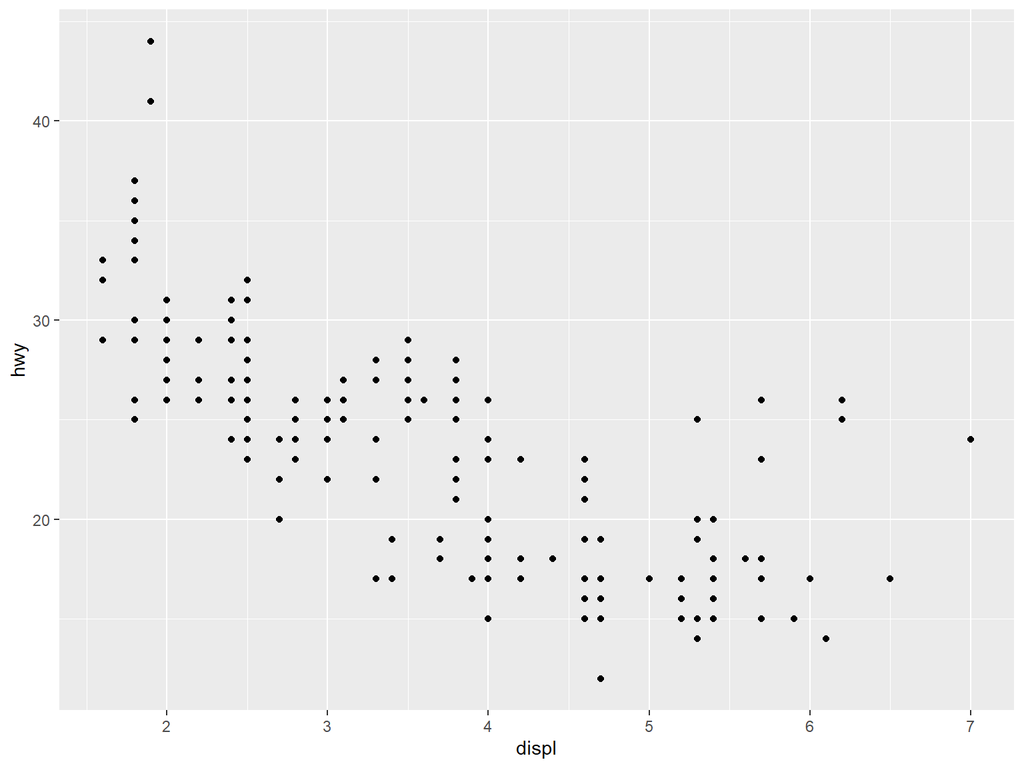

```r
    library(ggplot2) #library(tidyverse)
    ggplot()+
      geom_point(data = mpg,
                 mapping = aes(x = displ,y = hwy))
```

# Aesthetic Mappings

### **Add an additional variable**

**color**

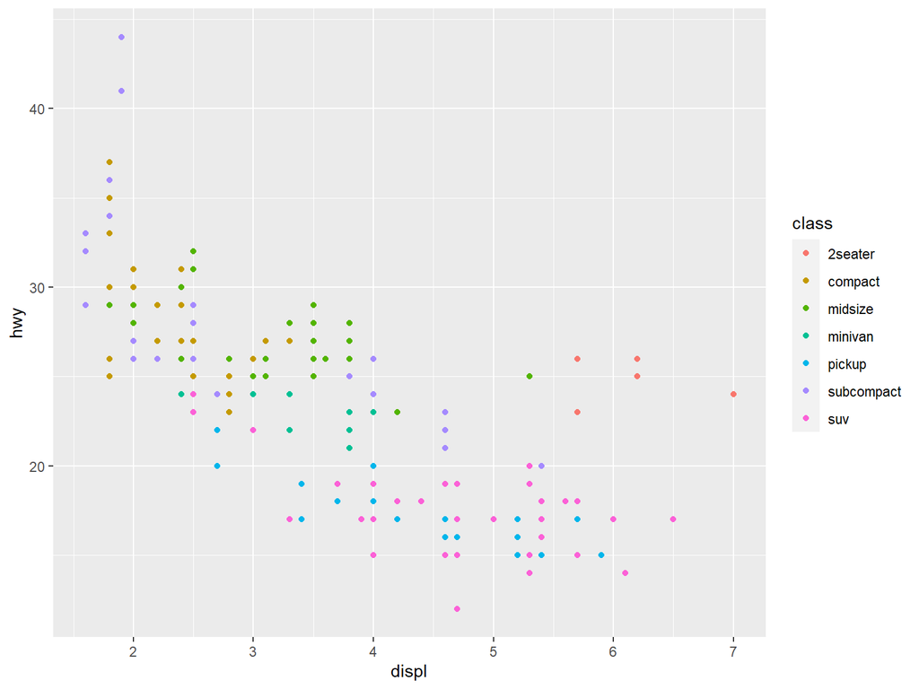

```r
    ggplot()+
      geom_point(data = mpg,
                 mapping = aes(x = displ,y = hwy, color = class))
```

# shape

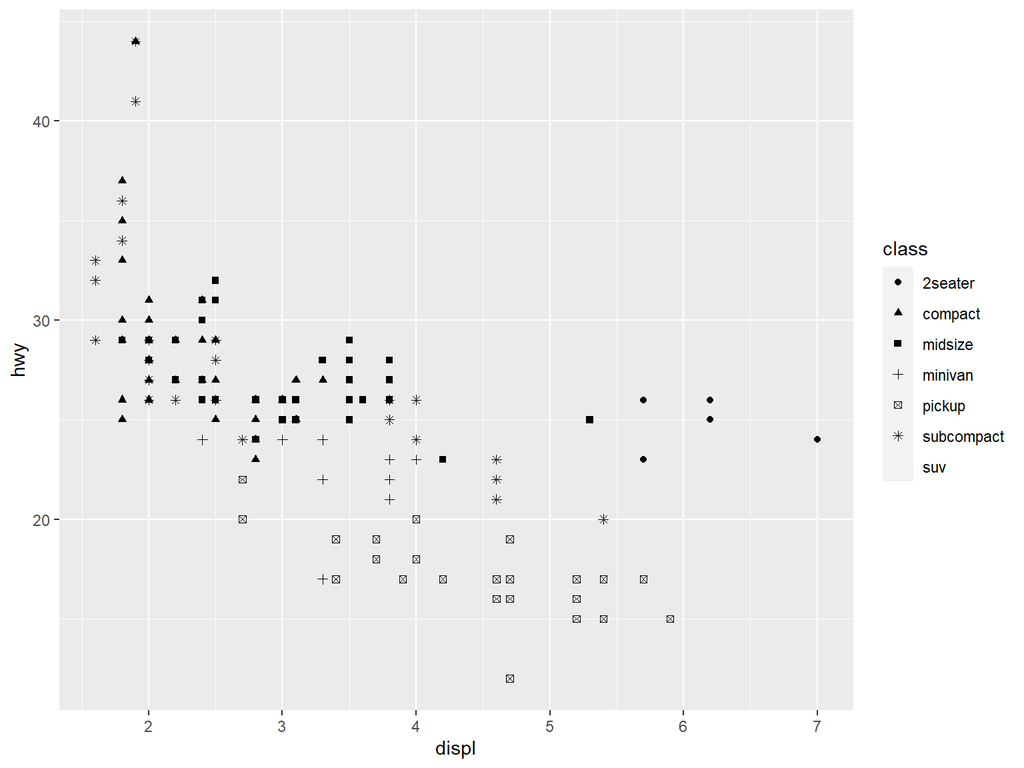

```r
    ggplot()+
      geom_point(data = mpg,
                 mapping = aes(x = displ,y = hwy, shape = class))
```

# transparency

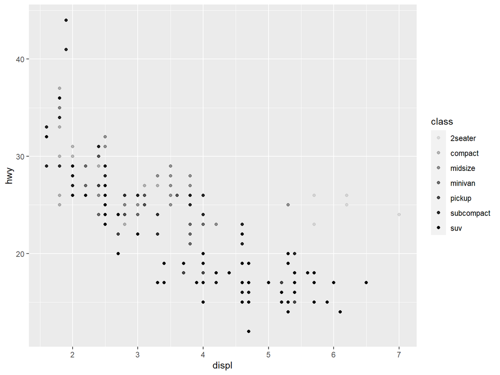

```r
    ggplot()+
      geom_point(data = mpg,
                 mapping = aes(x = displ,y = hwy, alpha = class))
```

# **Programming considerations**

- **Plus sign**

  ggplot(data = mpg)

  + geom_point(mapping = aes(x = displ, y = hwy))
- **color option**

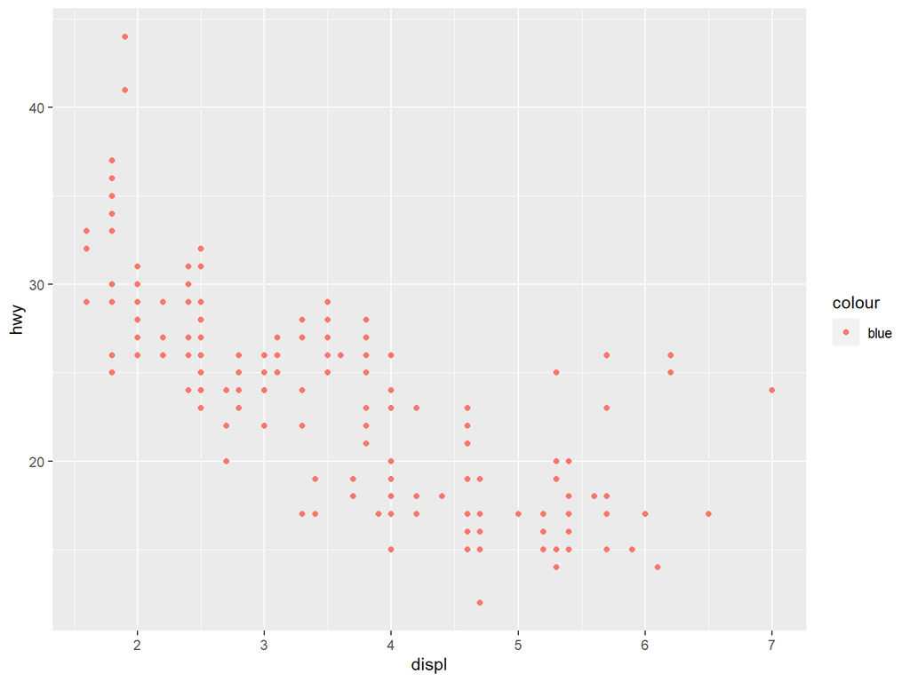

```r
    ggplot()+
      geom_point(data = mpg,
                 mapping = aes(x = displ,y = hwy, color = "blue"))
```

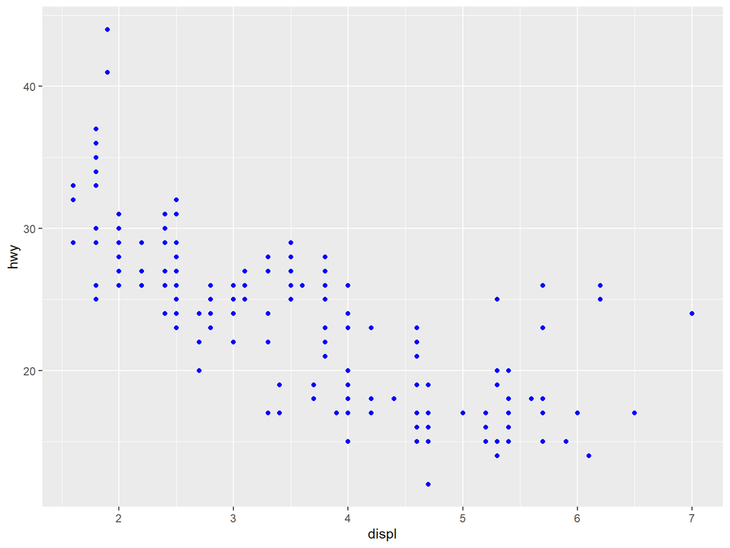

```r
    ggplot()+
      geom_point(data = mpg,
                 mapping = aes(x = displ,y = hwy), color = "blue")
```

# Facets

**facet_wrap**

facet the plot by a single variable, using ~sign

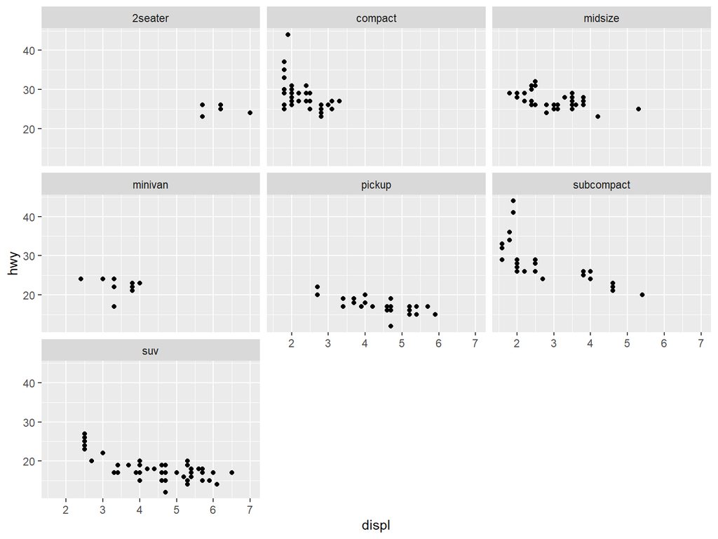

```r
    ggplot()+
      geom_point(data = mpg,
                 mapping = aes(x = displ,y = hwy))+
                 facet_wrap(~class)
```

scale = “fixed”/ “free”/ “free_x”/ “free_y”

nrow / ncol = n

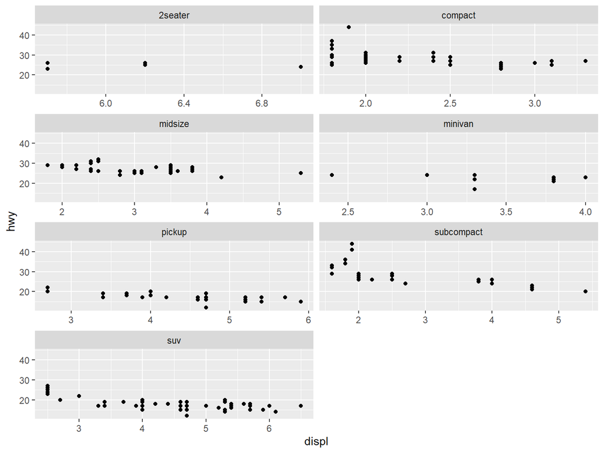

```r
    ggplot()+
      geom_point(data = mpg,
                 mapping = aes(x = displ,y = hwy))+
                 facet_wrap(~class, scale = "free_x",nrow = 4)
```

# **facet_grid**

facet the plot by two variables, using ~ sign to connect (row~col)

use . sign to replace (. ~ class)

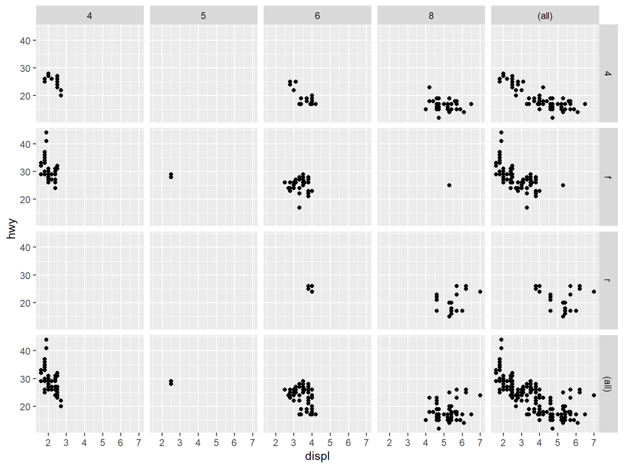

```r
    ggplot()+
      geom_point(data = mpg,
                 mapping = aes(x = displ,y = hwy))+
                 facet_grid(drv~cyl,margins=TRUE)
```

# Geometric Objects

Geometric objects represent the graphic elements we actually see in the diagram, such as points, lines, polygons, and so on.

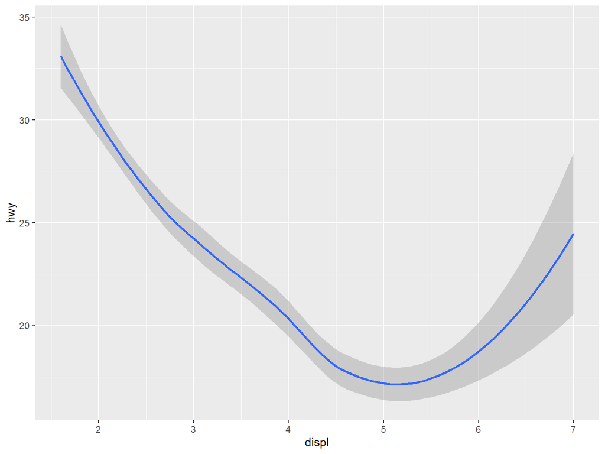

```r
    ggplot()+
      geom_smooth(data = mpg,
                 mapping = aes(x = displ,y = hwy))
```

# Histogram

```r
data(diamonds)
set.seed(1234)
diamond <- diamonds[sample(nrow(diamonds), 2000), ]
head(diamond)
```

```
## # A tibble: 6 x 10
##   carat cut       color clarity depth table price     x     y     z
##   <dbl> <ord>     <ord> <ord>   <dbl> <dbl> <int> <dbl> <dbl> <dbl>
## 1  0.61 Good      E     I1       63.4  57.1  1168  5.37  5.43  3.42
## 2  0.53 Premium   G     SI2      60.8  58    1173  5.21  5.19  3.16
## 3  0.23 Very Good E     VVS2     62.3  55     505  3.9   3.93  2.44
## 4  1.33 Ideal     J     VS1      61.3  57    6118  7.11  7.08  4.35
## 5  0.3  Ideal     E     VVS1     61.6  56     838  4.3   4.34  2.66
## 6  0.3  Ideal     D     VS2      60.8  57     911  4.34  4.31  2.63
```

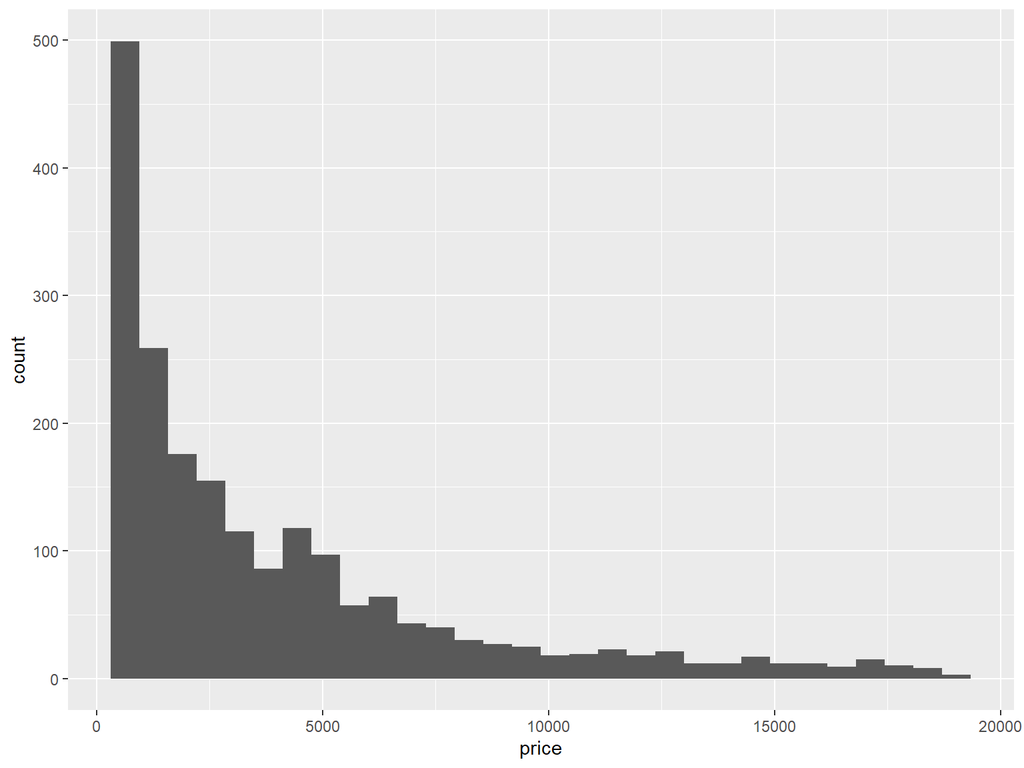

```r
ggplot()+
      geom_histogram(data = diamond,
                 mapping = aes(x = price))
```

# Bar plot

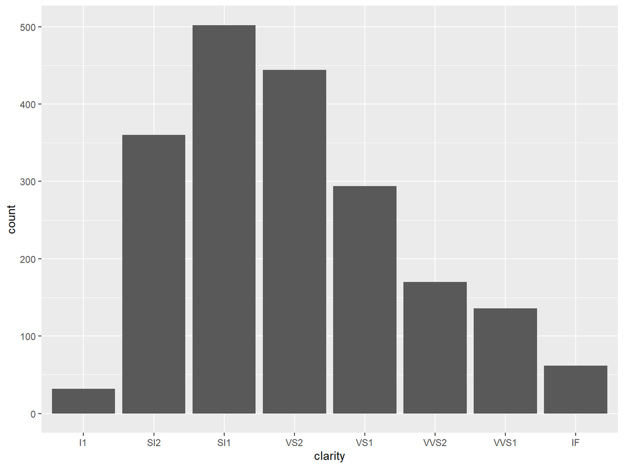

```r
    ggplot()+
      geom_bar(data = diamond,
                 mapping = aes(x = clarity))
```

# Box plot

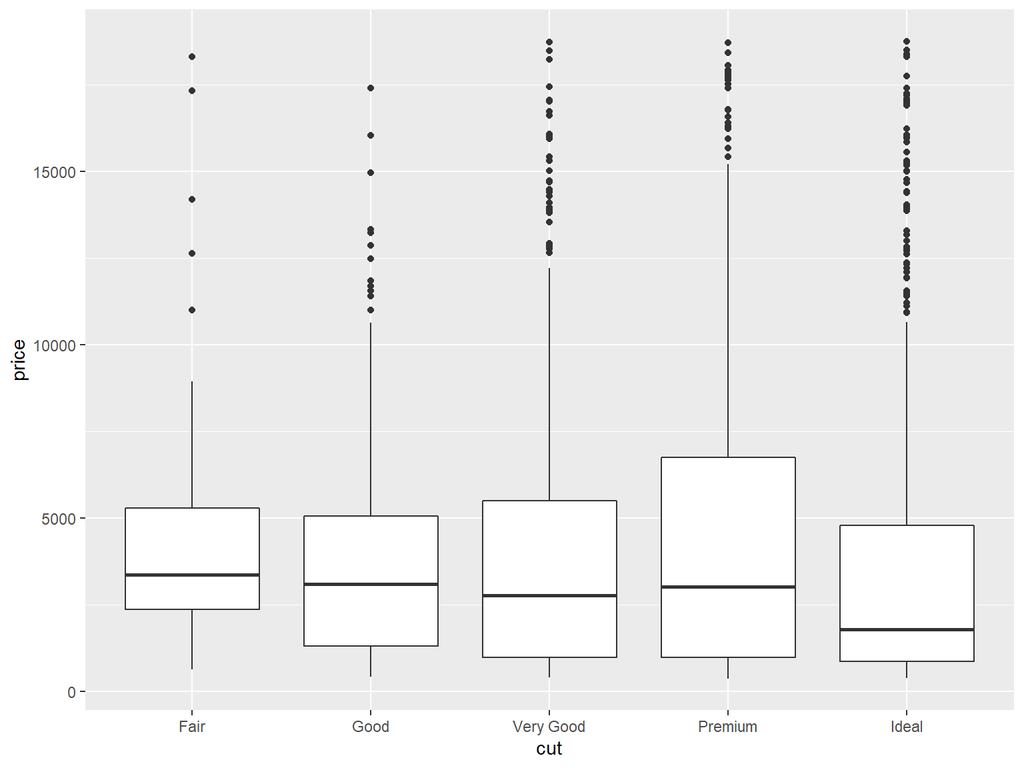

```r
    ggplot()+
      geom_boxplot(data = diamond,
                 mapping = aes(x=cut, y=price))
```

# geom_

```
ggplot2::geom_
```

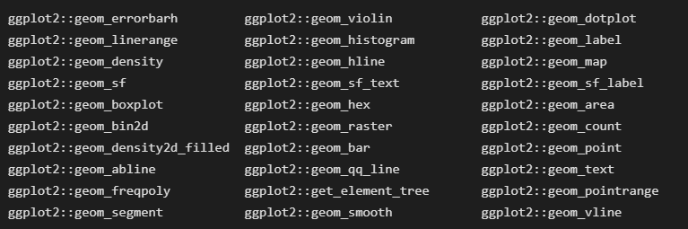

# Statistical Transformations

```
ggplot(data = diamonds) +
geom_bar(mapping = aes(x = cut))
```

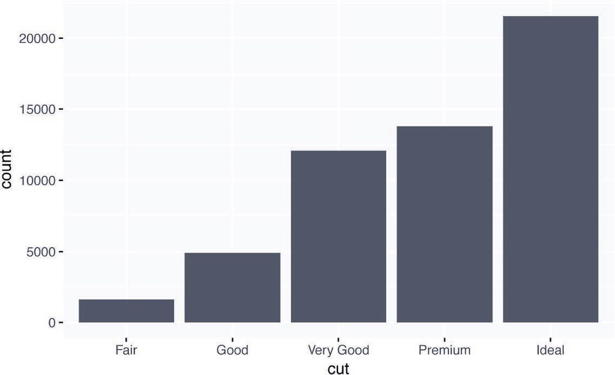

# Statistical Transformations

- Bar charts, histograms, and frequency polygons bin your data and then plot bin counts, the number of points that fall in each bin.
- Smoothers fit a model to your data and then plot predictions from the model.
- Boxplots compute a robust summary of the distribution and display a specially formatted box.

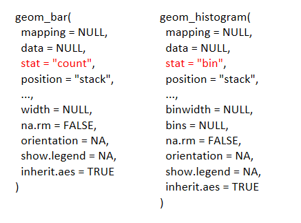

# Statistical Transformations

You can generally use geoms and stats interchangeably. For example, you can re-create the previous plot using stat_count() instead of geom_bar():

```
ggplot(data = diamonds) +
stat_count(mapping = aes(x = cut))
```

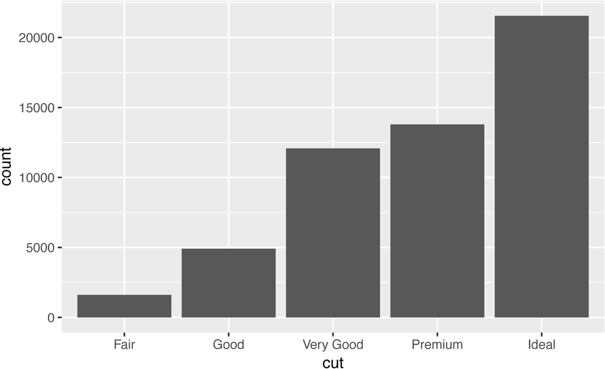

# stat_summary

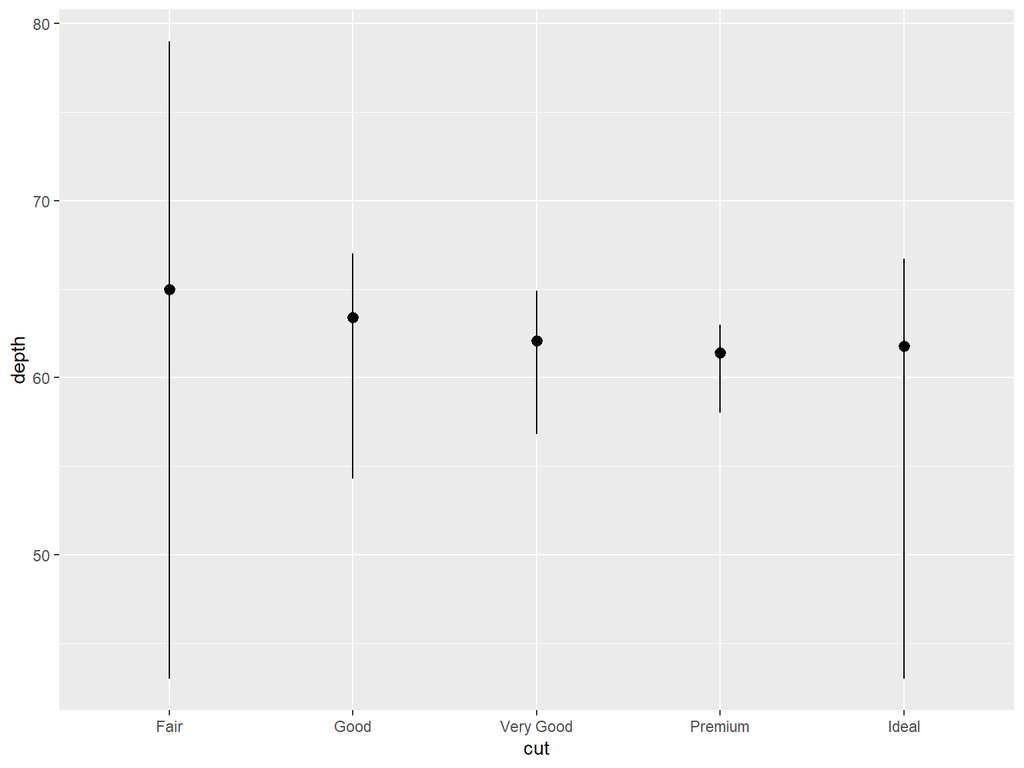

```r
ggplot(data = diamonds) +
stat_summary(
mapping = aes(x = cut, y = depth),
fun.min = min,
fun.max = max,
fun = median
)
```

# stat_smooth

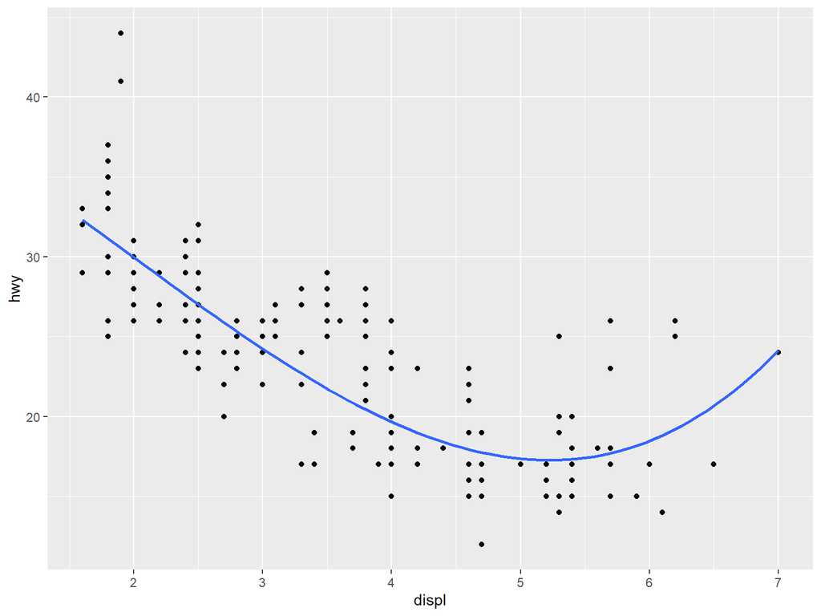

```r
ggplot(mpg, aes(displ, hwy)) +
geom_point() +
stat_smooth(method = lm, formula = y ~ splines::bs(x, 3), se = FALSE)
```

# Position Adjustments

### fill

```
#Fill colors by cut classification
ggplot() +
geom_bar(data = diamonds, mapping = aes(x = cut, fill = cut))
#fill colors by clarity classification
ggplot() +
geom_bar(data = diamonds, mapping = aes(x = cut, fill = clarity))
```

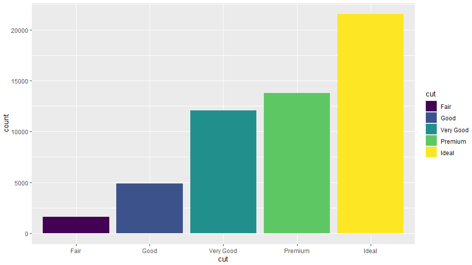

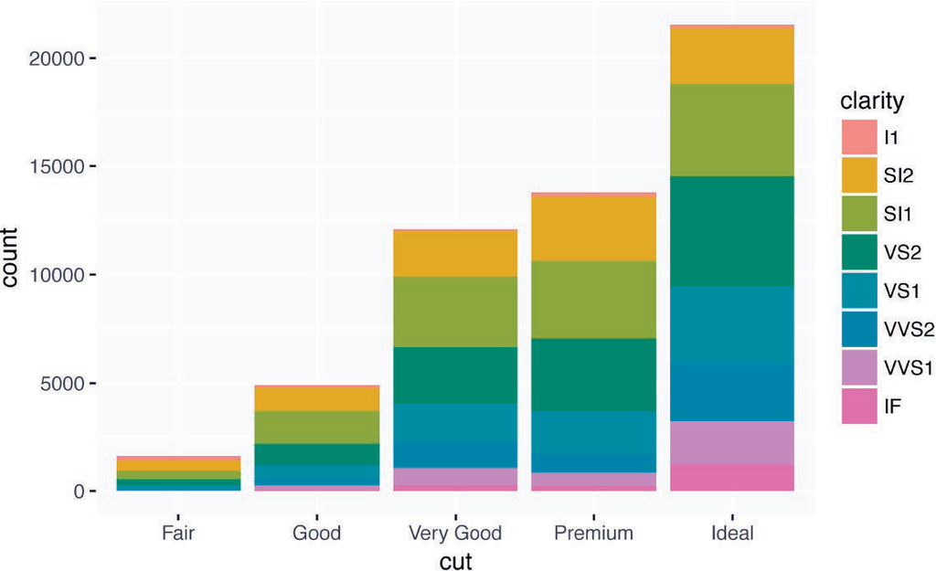

# position

### identity

```
ggplot(data = diamonds, mapping = aes(x = cut, fill = clarity)) +
geom_bar(alpha = 1/5, position = "identity")
```

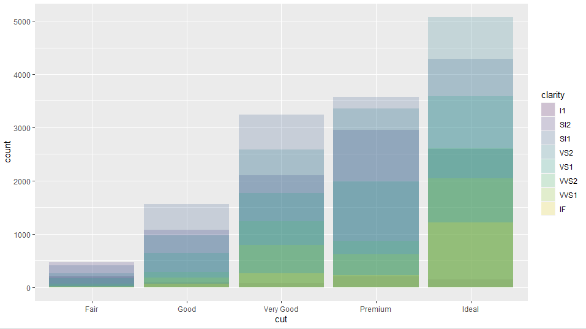

```
ggplot(data = diamonds, mapping = aes(x = cut, color = clarity)) +
    geom_bar(fill = NA, position = "identity")
```

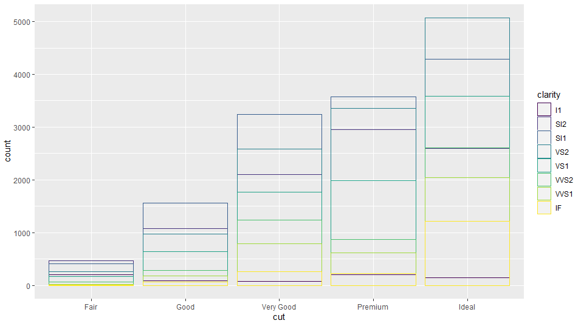

# fill

```
ggplot(data = diamonds) +
    geom_bar(mapping = aes(x = cut, fill = clarity), position = "fill")
```

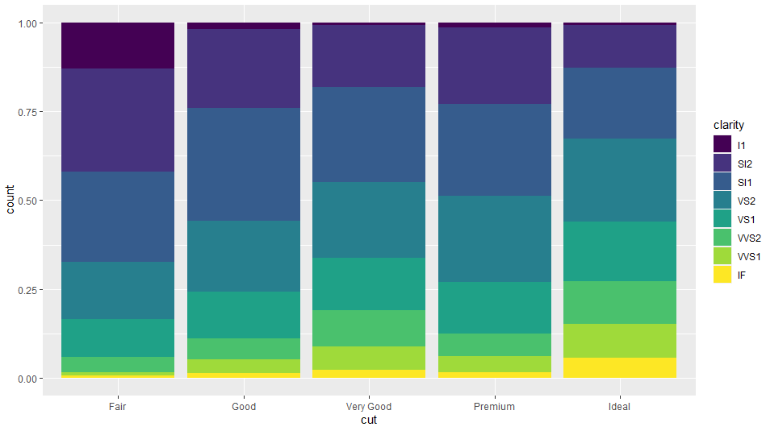

# dodge

```
ggplot(data = diamonds) +
    geom_bar(mapping = aes(x = cut, fill = clarity), position = "dodge")
```

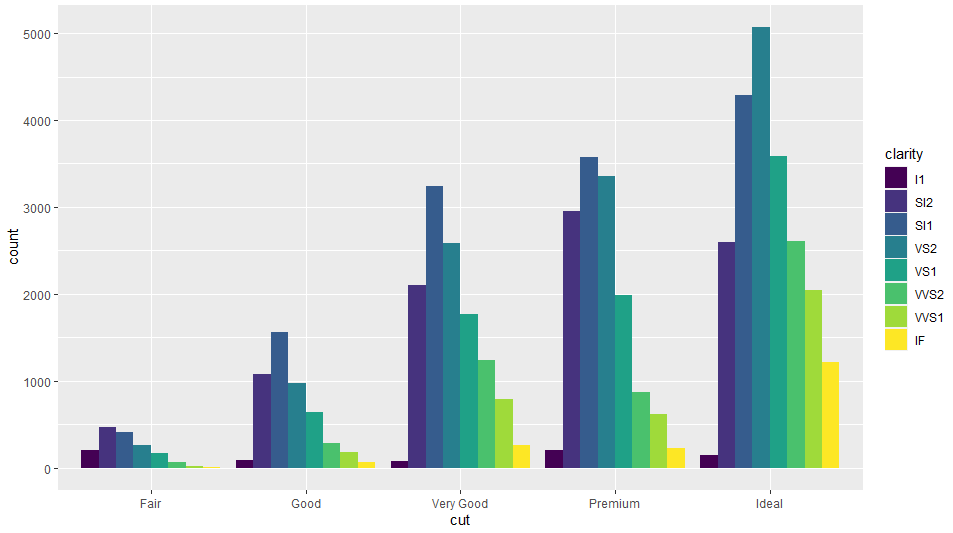

# Coordinate Systems

### Axes

coord_flip() switches the x- and y-axes.

```
ggplot(data = mpg, mapping = aes(x = class, y = hwy)) +
geom_boxplot()
```

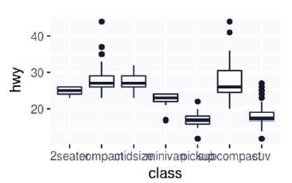

```
ggplot(data = mpg, mapping = aes(x = class, y = hwy)) +
geom_boxplot()+
coord_flip()
```

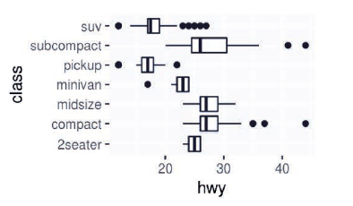

# Maps

coord_quickmap() sets the aspect ratio correctly for maps.

```
nz <- map_data("nz")
ggplot(nz, aes(long, lat, group = group)) +
geom_polygon(fill = "white", color = "black")
ggplot(nz, aes(long, lat, group = group)) +
geom_polygon(fill = "white", color = "black") +
coord_quickmap()
```

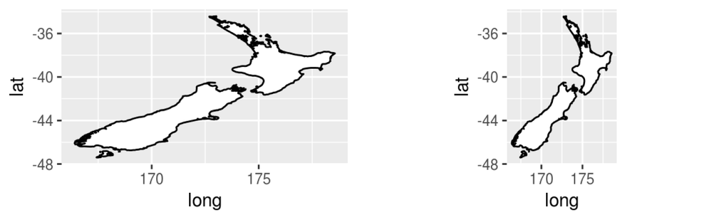

# Polar

coord_polar() uses polar coordinates.

```
bar <- ggplot(data = diamonds) +
geom_bar(
mapping = aes(x = cut, fill = cut),
show.legend = FALSE,
width = 1
) +
theme(aspect.ratio = 1) +
labs(x = NULL, y = NULL)
bar + coord_flip()
bar + coord_polar()
```

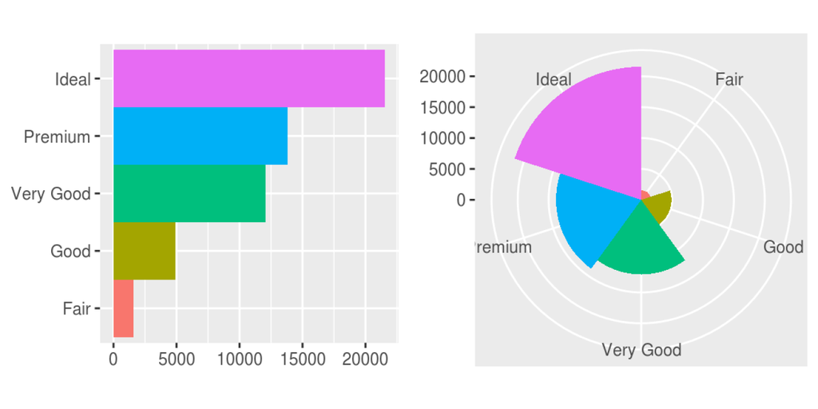